# R Final Project

Kaitlin Van Volkom

12/6/2021

## Introduction

American lobsters have been named America’s most important fishery, with landings and market value increasing (Le Bris et al. 2018). While Cancer crab landings are not nearly as high as lobster landings, fishing intensity has increased substantially in the last few years and they are considered a developing fishery. Concurrently, ocean temperature in Gulf of Maine is increasing and there is great potential for range expansions from southerly species, increasing the frequency of successful invasions, and contractions or expansions in local species populations (Pershing et al. 2015). One such population that is shifting is the native slipper limpet (Crepidula fornicata). Our field observations suggest their populations have increased significantly in the past few decades, and though predation on limpets by lobsters and crabs is known, there have been no studies investigating the potential impacts of this mollusc on crustacean populations. Slipper limpet populations are expected to increase as their growth and reproductive potential is closely tied to temperature (Valdizan et al. 2011). As slipper limpet populations are just beginning to rise, this study gives us the opportunity to understand their effect on crustaceans in real-time and not after the fact, as so often is the case in the marine sciences.

Fisheries are predicted to change drastically in the next couple of decades, with new fisheries developed from more southernly species, and some species in the Southern Gulf of Maine migrating north. Combined, these changes indicate that our fisheries are likely to look quite different than they do at present and it is imperative to consider studies that incorporate a shifting prey species. Mussel populations have changed drastically over the past three decades, most likely as a result of warming waters. This species may be cold adapted, and further declines may occur as temperatures continue to warm (Sorte et al. 2017). Mussels are a common food source for many benthic predators in the Gulf of Maine, and while there may be periodic increases in their population, as was seen in the summer of 2021, their predators may have to search elsewhere for more stable food sources. While mussel populations have declined in the past decades, slipper limpet (Crepidula fornicata) populations appear to have increased. Research has shown that increases in water temperatures lead to substantial increases in the reproductive output of limpets (Valdizan et al. 2011). As soon as water temperatures are above 10°C, these limpets start breeding, and do not cease until water temperatures fall below 10°C. Therefore, as waters warm in the Gulf of Maine, it is likely that we will see increases in their population densities. This may be especially prominent in Northern locations that have been historically colder.

The slipper limpet is unique in that it forms stacks of 2-14 individuals. Though its population size will vary with water temperature, the species is observed in subtidal rocky seafloors and is distributed throughout the coastal Eastern seaboard Though, this species is widely distributed across their native range, much of their ecology is still unknown. There have been documented cases of predation on limpets by cancer crabs, green crabs, and lobsters (Pechenik, Ambrogio, and Untersee 2010), but few studies have thoroughly investigated the extent to which predators rely on limpets as a food source or their nutritional quality relative to the crustaceans historical food source. This leaves a very large potential prey population about which we know very little.

Studying these increasing populations of limpets is crucial to understanding how our benthic communities, and the fishery species that rely on them, will change in the future. Limpets are highly invasive in regions off the coast of France and England, and have had profound effects on their benthic environments (Blanchard 1997). They have outcompeted local bivalves such as mussels and oysters, and have also drastically decreased the amount of plankton in the water column, as they are effective filter feeders. This has led to increases in the rates of sedimentation in rocky habitats, and may contribute to local benthic anoxic zones (De Montaudouin and Sauriau 1999). Mussel populations are greatly reduced, and when they are available in the ecosystem they are only available for short periods of time and are heavily preyed on by a myriad of predators. Though limpets may not be the preferred prey of crustacean predators, they may be a more reliable, stable, food source as they are present in high densities throughout the year. We do not yet know how these populations are affecting crustacean species, but they may be an important factor for managing healthy, sustainable fisheries.

## Methods

A series of limpet population surveys were conducted throughout New England in the summer of 2021 between July and September. Sites were selected for their rocky shorelines and benthic habitats. Surveys were conducted from Portland, ME to Rhode Island. The sites survey were as follows, ME: Nubble Lighthouse; Dyer Cover, Portland; Fort Williams St Park, Portland; NH: Pulpit Rocks, Rye; Gosport Harbor; White Island; Fort Stark, New Castle; MA: Chandler Hovey Lighthouse, Marblehead; Canoe beach, Nahant; Folly Cove, Rockport; Grapevine Rd, Gloucester, RI: Gull Cove, Portsmouth; Brenton Point St Park, Newport; Beavertail St Park, Jamestown. Divers surveyed hard bottom communities for limpets via SCUBA diving with 0.25m2 quadrats. The quadrat was placed onto a rocky surface, and 20 stacks of limpets were collected and placed into a sectioned, plastic container. The other remaining stacks were counted and recorded. This process was repeated 4-6 times at each site. The quadrats were placed haphazardly on surfaces larger than 0.25m2, and were at least 1m apart from one another. The depths of these dives ranged from 4-7m and all were close to shore. For each stack that was collected, we recorded the number of limpets in each stack, the position of that individual within the stack, and the shell length of each animal.

## Results

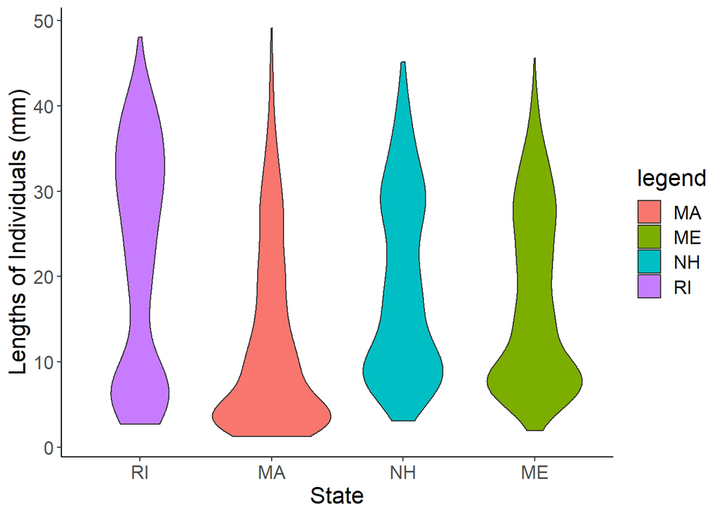

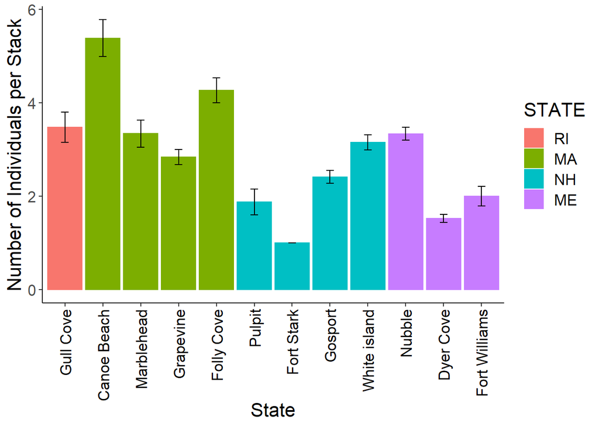

Number of Limpets Within a Stack in Differnt Sites. Error bars are the standard error

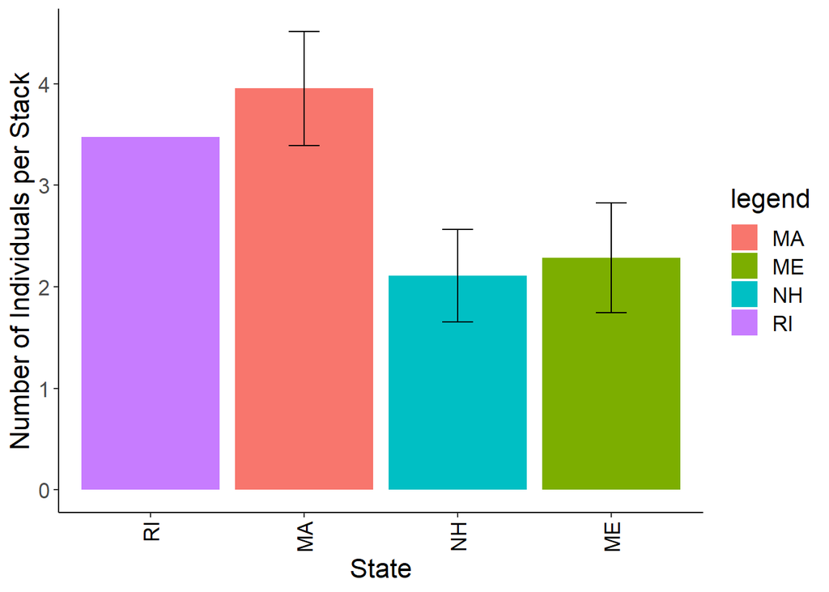

Number of Limpets in a Stack by State. Error bars are the standard error

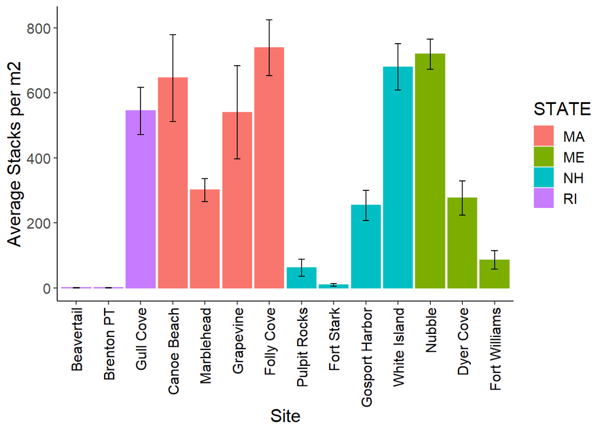

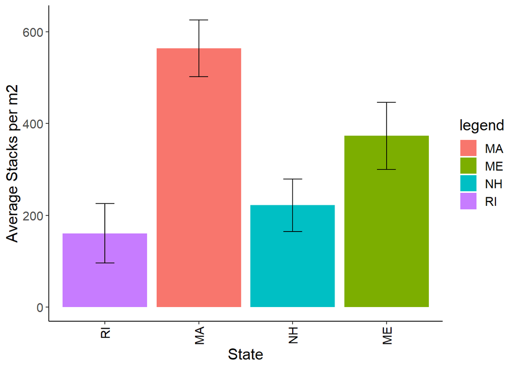

Average Number of Stacks of Limpets per m2 by State. Error bars are the standard error

## Conclusions

The number of limpets counted in this survey were far higher than anticipated. I had expected that there would be stronger latitudinal patterns than were seen in the sites surveyed this summer. There was more variation within sites than I was expecting, with some sites that should have been optimal habitat having no limpets present. In the future, I would like to look at the exposure of the site and how that might relate to limpet densities. It’s possible that at sheltered sites the larvae has more time to settle out of the water column, potentially leading to higher densities. I was surprised how few limpets per stack there were at each site, as the literature describes stacks of 2-14 individuals, and my numbers were no where near the upper end of that range. Differences in temperature and resource availability may account for smaller stacks, as I’ve heard that they are taller in the South. Theses surveys confirm the need to directly study this population, as they represent a large portion of benthic biomass that has been overlooked.

## Next Steps

I would like to look at this data without including the smallest size classes. My surveys were done during their period of recruitment, and I counted many limpets that will likely experience mortality soon after settling. I would also like to examine differences in the number of individuals within each size class to see if that varies by state. Additionally, I need to run statistics on these data to determine if there are actual differences between sites and states.

## References

Blanchard, Michel. 1997. “Spread of the slipper limpet Crepidula fornicata (L. 1758) in Europe. Current state and consequences.” *Scientia Marina* 61 (SUPPL.2): 109–18.

De Montaudouin, X., and P. G. Sauriau. 1999. “The proliferating Gastropoda Crepidula fornicata may stimulate macrozoobenthic diversity.” *Journal of the Marine Biological Association of the United Kingdom* 79 (6): 1069–77. https://doi.org/10.1017/S0025315499001319.

Le Bris, Arnault, Katherine E. Mills, Richard A. Wahle, Yong Chen, Michael A. Alexander, Andrew J. Allyn, Justin G. Schuetz, James D. Scott, and Andrew J. Pershing. 2018. “Climate vulnerability and resilience in the most valuable North American fishery.” *Proceedings of the National Academy of Sciences of the United States of America* 115 (8): 1831–36. https://doi.org/10.1073/pnas.1711122115.

Pechenik, Jan A., Olivia V. Ambrogio, and Steven Untersee. 2010. “Predation on juveniles of Crepidula fornicata by two crustaceans and two gastropods.” *Journal of Experimental Marine Biology and Ecology* 384 (1-2): 91–98. https://doi.org/10.1016/j.jembe.2009.12.011.

Pershing, Andrew J., Michael A. Alexander, Christina M. Hernandez, Lisa A. Kerr, Arnault L. Bris, Katherine E. Mills, Janet A. Nye, et al. 2015. “Slow adaptation in the face of rapid warming leads to collapse of the Gulf of Maine cod fishery.” *Science* 350 (6262): 809–12. https://doi.org/10.1126/science.aac9819.

Sorte, Cascade J. B., Victoria E. Davidson, Marcus C. Franklin, Kylla M. Benes, Meredith M. Doellman, Ron J. Etter, Robyn E. Hannigan, Jane Lubchenco, and Bruce A. Menge. 2017. “Long-term declines in an intertidal foundation species parallel shifts in community composition.” *Global Change Biology* 23 (1): 341–52. https://doi.org/10.1111/gcb.13425.

Valdizan, Alexandra, Peter G Beninger, Priscilla Decottignies, Marianne Chantrel, Bruno Cognie, Alexandra Valdizan, Peter G Beninger, Priscilla Decottignies, and Marianne Chantrel. 2011. “Evidence that rising coastal seawater temperatures increase reproductive output of the invasive gastropod Crepidula fornicata.” https://doi.org/10.3354/meps09281.